# Chicken Weights Analysis Report

Ghadi K

11-10-2020

In this report I worked with chickwts dataset it has two variables weight a numeric variable giving the chick weight and feed factor giving the feed type. This dataset is based on an experiment conducted to measure and compare the effectiveness of various feed supplements on the growth rate of chickens. This report focuses on the relationship between weight and food type and if a change in food type really affects chickens in any way.

# Descriptive Statistics

First I explore the data to understand it better using descriptive statistics. The table below shows the number of each food type, mean and standard deviation for each type. You can see that the most occurring food type is Soybean.

|  | feed | n | average | SD |
| --- | --- | --- | --- | --- |
| 1 | casein | 12 | 323.583333333333 | 64.4338396882391 |
| 2 | horsebean | 10 | 160.2 | 38.6258405158458 |
| 3 | linseed | 12 | 218.75 | 52.2356983471857 |
| 4 | meatmeal | 11 | 276.909090909091 | 64.9006233336084 |
| 5 | soybean | 14 | 246.428571428571 | 54.1290683824878 |
| 6 | sunflower | 12 | 328.916666666667 | 48.8363842257228 |

# Plots

Here I visualize data to see a pattern , trends and detect outliers if exists it is easier to understand these thing after visualize data set .

## Box Plot

First I plot Boxplot but why ? Boxplot can give you information regarding the shape, variability, and center (or median) of a statistical data set.

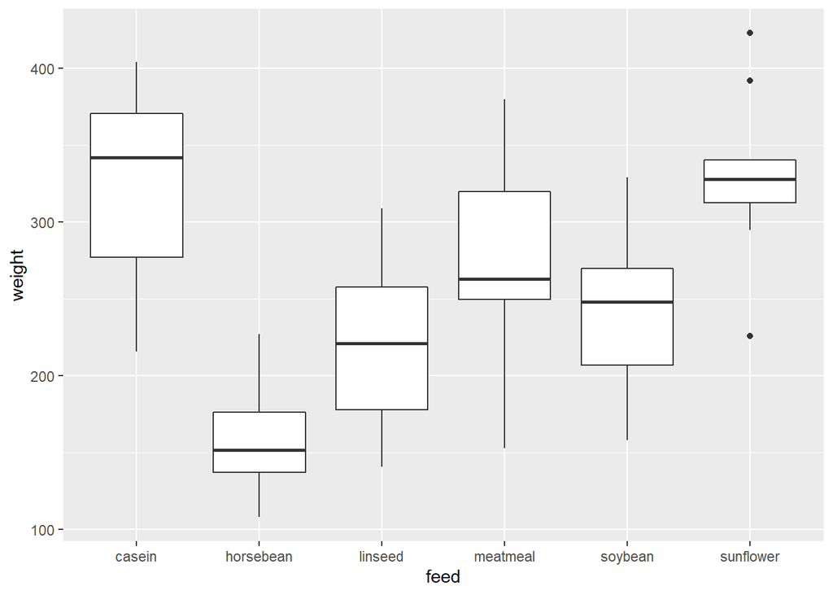

## Jitter Plot

The second is the jitter plot but why? To see the relationship between our variables here they are weight and feed also it is shown how much one variable is affected by another.

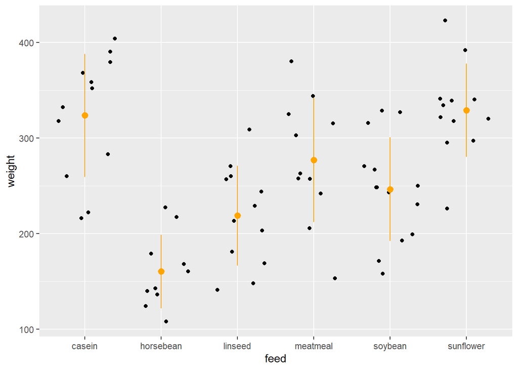

# Inferential Statistics

Here I apply the ANOVA test to determine whether there are any statistically significant differences between the means of two or more independent.

## The one-way ANOVA summary

Analysis of Variance Model The value of F here is high then the difference among groups is deemed statistically significant.

|  | Df | Sum Sq | Mean Sq | F value | Pr(>F) |
| --- | --- | --- | --- | --- | --- |
| **feed** | 5 | 231129 | 46226 | 15.36 | 5.936e-10 |
| **Residuals** | 65 | 195556 | 3009 | NA | NA |

## Tukey’s Post-hoc test

|  | diff | lwr | upr | p adj |
| --- | --- | --- | --- | --- |
| horsebean-casein | -163.383333333333 | -232.346876204447 | -94.4197904622199 | 3.07019679679499e-08 |
| linseed-casein | -104.833333333333 | -170.587491482774 | -39.0791751838921 | 0.000210015132161567 |
| meatmeal-casein | -46.6742424242424 | -113.906206623052 | 20.5577217745669 | 0.332458415973003 |
| soybean-casein | -77.1547619047618 | -140.517054139431 | -13.7924696700929 | 0.00836530868305818 |
| sunflower-casein | 5.33333333333326 | -60.4208248161079 | 71.0874914827744 | 0.999890217393269 |
| linseed-horsebean | 58.55 | -10.4135428711134 | 127.513542871113 | 0.141332894456581 |
| meatmeal-horsebean | 116.709090909091 | 46.3351046540537 | 187.083077164128 | 0.000106209151476744 |
| soybean-horsebean | 86.2285714285714 | 19.541683597261 | 152.915459259882 | 0.00421665424383655 |
| sunflower-horsebean | 168.716666666666 | 99.7531237955531 | 237.68020953778 | 1.2198866583546e-08 |
| meatmeal-linseed | 58.1590909090908 | -9.07287328971852 | 125.3910551079 | 0.127696481749042 |

[output cut: 5 more lines]

So I conclude at the end of this report that the groups are truly statistically significant.